# Tugas Individu 3 - Regresi Lag MPDW

Ravi Mahesa Pramudya (G1401211052)

```r
library(dLagM)
library(dynlm)
library(MLmetrics)
library(lmtest)
library(readxl)
```

# Input data

```r
Repsol_Stock <- read_excel("~/SMT5/MPDW/Repsol Stock.xlsx",
    sheet = "Lag")
View(Repsol_Stock)
```

# Pembagian data dan data time series

```r
train <- Repsol_Stock[1:168,]
test <- Repsol_Stock[168:210,]

data.ts <- ts(Repsol_Stock)
train.ts <- ts(train)
test.ts <- ts(test)
```

# 1. Model Koyck

```r
model.koyck <- koyckDlm(x = train$High, y = train$Volume, intercept = TRUE)
summary(model.koyck)
```

```
##
## Call:
## "Y ~ (Intercept) + Y.1 + X.t"
##
## Residuals:
##       Min        1Q    Median        3Q       Max
## -13351335  -3260073  -1692346   1182173  42117763
##
## Coefficients:
##               Estimate Std. Error t value Pr(>|t|)
## (Intercept)  9.616e+06  5.187e+06   1.854   0.0655 .
## Y.1          4.562e-01  7.008e-02   6.510 8.78e-10 ***
## X.t         -3.456e+05  3.882e+05  -0.890   0.3747
## ---
## Signif. codes:  0 '***' 0.001 '**' 0.01 '*' 0.05 '.' 0.1 ' ' 1
##
## Residual standard error: 6672000 on 164 degrees of freedom
## Multiple R-Squared: 0.2179,  Adjusted R-squared: 0.2084
## Wald test: 23.11 on 2 and 164 DF,  p-value: 1.443e-09
##
## Diagnostic tests:
## NULL
##
##                             alpha      beta       phi
## Geometric coefficients:  17681237 -345553.8 0.4561602
```

```r
AIC(model.koyck)
```

```
## [1] 5727.191
```

```r
BIC(model.koyck)
```

```
## [1] 5739.663
```

### Peramalan dan akurasi model koyck

```r
# peramalan 40 periode kedepan
frc.koyck <- forecast(model = model.koyck, x=test$High, h=43)
frc.koyck
```

```
## $forecasts
##  [1]  6632621  7924488  8456770  8905181  9184022  9160902  9038051  8956094
##  [9]  8979181  9179767  9252261  9190302  9229422  9321561  9399874  9623925
## [17]  9805605  9874658  9845685  9906763 10015830 10221081 10233503 10170059
## [25] 10154940 10103122  9991368  9809080  9667183  9571355  9579476  9581452
## [33]  9718848  9741783  9657218  9530527  9472735  9482656  9473359  9308436
## [41]  9290221  9217985  9198856
##
## $call
## forecast.koyckDlm(model = model.koyck, x = test$High, h = 43)
##
## attr(,"class")
## [1] "forecast.koyckDlm" "dLagM"
```

```r
#akurasi data test
mape.koyck <- MAPE(frc.koyck$forecasts, test$Volume)
mape.koyck
```

```
## [1] 0.9493397
```

```r
#akurasi data training
GoF(model.koyck)
```

|  | n | MAE | MPE | MAPE | sMAPE | MASE | MSE | MRAE | GMRAE |
| --- | --- | --- | --- | --- | --- | --- | --- | --- | --- |
| model.koyck | 167 | 3940263 | -0.2652487 | 0.4587288 | 0.3838962 | 0.919303 | 4.371779e+13 | 3.53749 | 1.111256 |

# 2. Model Distributed Lag

### dengan lag 3

```r
model.dl <- dlm(x = train$High, y = train$Volume, q=3)
summary(model.dl)
```

```
##
## Call:
## lm(formula = model.formula, data = design)
##
## Residuals:
##      Min       1Q   Median       3Q      Max
## -6505009 -3831299 -1725803  1268993 47103558
##
## Coefficients:
##             Estimate Std. Error t value Pr(>|t|)
## (Intercept) 12970608    5021183   2.583   0.0107 *
## x.t         -1614731    2045085  -0.790   0.4309
## x.1          2891230    3036796   0.952   0.3425
## x.2         -1326309    3035868  -0.437   0.6628
## x.3          -245178    2026886  -0.121   0.9039
## ---
## Signif. codes:  0 '***' 0.001 '**' 0.01 '*' 0.05 '.' 0.1 ' ' 1
##
## Residual standard error: 6715000 on 160 degrees of freedom
## Multiple R-squared:  0.009288,   Adjusted R-squared:  -0.01548
## F-statistic: 0.375 on 4 and 160 DF,  p-value: 0.8262
##
## AIC and BIC values for the model:
##        AIC      BIC
## 1 5662.709 5681.345
```

```r
AIC(model.dl)
```

```
## [1] 5662.709
```

```r
BIC(model.dl)
```

```
## [1] 5681.345
```

Dari hasil diatas, didapat bahwa $P-value$ dari intercept<0.05$. Hal ini menunjukkan bahwa intercept berpengaruh signifikan terhadap $y_t$. Adapun model keseluruhan yang terbentuk adalah sebagai berikut

$$\hat{Y_t}=12970608-
1614731X_t+2891230X_{t-1}-1326309X_{t-2}-245178X_{t-3}$$

### Peramalan dan akurasi model Distributed Lag (lag=3)

```r
# peramalan 40 periode kedepan
frc.dl <- forecast(model = model.dl, x=test$High, h=43)
frc.dl
```

```
## $forecasts
##  [1]  8853229  8789507  8842590 10141145  8523449  7948125  9112057  9406374
##  [9]  9368090  9571071  8105800  8593144  9765004  9170163  8909300  9818717
## [17]  8806361  8825369  9097114  9953586  9469521  9758962  8442844  9453791
## [25]  9895273  9246831  9214951  9176004  9630085  9409750  9593532  8990723
## [33]  9819879  8522296  8933402  9261052  9605386  9369300  8938612  8442673
## [41] 10026218  8623896  9328198
##
## $call
## forecast.dlm(model = model.dl, x = test$High, h = 43)
##
## attr(,"class")
## [1] "forecast.dlm" "dLagM"
```

```r
#akurasi data test
mape.dl <- MAPE(frc.dl$forecasts, test$Volume)
mape.dl
```

```
## [1] 0.8968696
```

```r
#akurasi data training
GoF(model.dl)
```

|  | n | MAE | MPE | MAPE | sMAPE | MASE | MSE | MRAE | GMRAE |
| --- | --- | --- | --- | --- | --- | --- | --- | --- | --- |
| model.dl | 165 | 4188589 | -0.3221851 | 0.5279613 | 0.4273735 | 1.02359 | 4.372086e+13 | 5.1111 | 1.340431 |

### dengan lag Optimmum

```r
# cari lag optimum
finiteDLMauto(formula =Volume ~ High,
              data = data.frame(Repsol_Stock), q.min = 1, q.max = 6,
              model.type = "dlm", error.type = "AIC", trace = FALSE)
```

|  | q - k | MASE | AIC | BIC | GMRAE | MBRAE | R.Adj.Sq | Ljung-Box |
| --- | --- | --- | --- | --- | --- | --- | --- | --- |
| 6 | 6 | 1.051 | 6976.574 | 7006.437 | 1.34654 | 0.7873 | -0.01848 | 9.973133e-13 |

Berdasarkan output tersebut, lag optimum didapatkan ketika lag=6. Selanjutnya dilakukan pemodelan untuk lag=6

### Dengan lag optimum (lag=6)

```r
model.dl.opt <- dlm(x = train$High, y = train$Volume, q=6)
summary(model.dl.opt)
```

```
##
## Call:
## lm(formula = model.formula, data = design)
##
## Residuals:
##      Min       1Q   Median       3Q      Max
## -7244083 -3948722 -1671653  1366710 46922084
##
## Coefficients:
##             Estimate Std. Error t value Pr(>|t|)
## (Intercept) 13856046    5229329   2.650   0.0089 **
## x.t         -1775847    2084174  -0.852   0.3955
## x.1          2887489    3093188   0.933   0.3520
## x.2         -1384092    3095104  -0.447   0.6554
## x.3          1712544    3085623   0.555   0.5797
## x.4         -1865203    3103905  -0.601   0.5488
## x.5         -1362467    3106785  -0.439   0.6616
## x.6          1428204    2071481   0.689   0.4916
## ---
## Signif. codes:  0 '***' 0.001 '**' 0.01 '*' 0.05 '.' 0.1 ' ' 1
##
## Residual standard error: 6793000 on 154 degrees of freedom
## Multiple R-squared:  0.01847,    Adjusted R-squared:  -0.02614
## F-statistic: 0.414 on 7 and 154 DF,  p-value: 0.8925
##
## AIC and BIC values for the model:
##        AIC      BIC
## 1 5566.503 5594.291
```

```r
AIC(model.dl.opt)
```

```
## [1] 5566.503
```

```r
BIC(model.dl.opt)
```

```
## [1] 5594.291
```

Dari hasil diatas, didapat bahwa $P-value$ dari intercept<0.05$. Hal ini menunjukkan bahwa intercept berpengaruh signifikan terhadap $y_t$. Adapun model keseluruhan yang terbentuk adalah sebagai berikut
$$\hat{Y_t}=13856046-1775847 X_t+
2887489X_{t-1}-1384092X_{t-2}+1712544X_{t-3}-1865203X_{t-4}-1362467X_{t-5}+1428204X_{t-6}$$

### Peramalan dan akurasi model Distributed Lag optimum (lag=6)

```r
# peramalan 40 periode kedepan
frc.dl.opt <- forecast(model = model.dl.opt, x=test$High, h=43)
frc.dl.opt
```

```
## $forecasts
##  [1]  8634597  8019368  8757489 10318329  8907827  8331950  7838655  8708575
##  [9] 10978374 10534338  7713274  7883861  8694577  9598300 10301633  9556540
## [17]  8236024  9134835  8534843  9825242 10469622 10647857  8178831  8942330
## [25]  9476144 10107870 10267435  8744578  9547360  9886813 10118660  8972680
## [33]  9579690  8114338  8913275  8742451  9810788 10446074  9274800  8023798
## [41]  9469644  8649609 10347990
##
## $call
## forecast.dlm(model = model.dl.opt, x = test$High, h = 43)
##
## attr(,"class")
## [1] "forecast.dlm" "dLagM"
```

```r
#akurasi data test
mape.dl.opt <- MAPE(frc.dl.opt$forecasts, test$Volume)
mape.dl.opt
```

```
## [1] 0.9063951
```

```r
#akurasi data training
GoF(model.dl.opt)
```

|  | n | MAE | MPE | MAPE | sMAPE | MASE | MSE | MRAE | GMRAE |
| --- | --- | --- | --- | --- | --- | --- | --- | --- | --- |
| model.dl.opt | 162 | 4243049 | -0.3224149 | 0.5340474 | 0.4311264 | 1.029196 | 4.386504e+13 | 5.088353 | 1.322033 |

# 3. Model Autoregressive

### Dengan lag p=1 dan q=1

```r
model.ardl <- ardlDlm(x = train$High, y = train$Volume, p = 1 , q = 1)
summary(model.ardl)
```

```
##
## Time series regression with "ts" data:
## Start = 2, End = 168
##
## Call:
## dynlm(formula = as.formula(model.text), data = data, start = 1)
##
## Residuals:
##       Min        1Q    Median        3Q       Max
## -10682136  -3240459  -1381864   1160984  42006763
##
## Coefficients:
##               Estimate Std. Error t value Pr(>|t|)
## (Intercept)  7.999e+06  5.075e+06   1.576    0.117
## X.t          3.008e+06  2.062e+06   1.459    0.147
## X.1         -3.253e+06  2.036e+06  -1.598    0.112
## Y.1          4.844e-01  7.143e-02   6.782 2.07e-10 ***
## ---
## Signif. codes:  0 '***' 0.001 '**' 0.01 '*' 0.05 '.' 0.1 ' ' 1
##
## Residual standard error: 6639000 on 163 degrees of freedom
## Multiple R-squared:  0.2304, Adjusted R-squared:  0.2163
## F-statistic: 16.27 on 3 and 163 DF,  p-value: 2.69e-09
```

```r
AIC(model.ardl)
```

```
## [1] 5726.504
```

```r
BIC(model.ardl)
```

```
## [1] 5742.094
```

Hasil di atas menunjukkan bahwa peubah $y_{t-1}$, hasil uji t menunjukkan nilai-p pada peubah $<0.05$ Hal ini menunjukkan bahwa peubah $y_{t-1}$ berpengaruh signifikan terhadap $y_t$, sementara $x_t$ dan $x_{t-1}$ tidak berpengaruh signifikan terhadap $y_t$. Model keseluruhannya adalah sebagai berikut:

$$\hat{Y}=7.999e+06+ 3.008e+06X_t-3.253e+06X_{t-1}+4.844e-01Y_{t-1}$$

### Peramalan dan akurasi model Autoregressive dengan lag (p=1 dan q=1)

```r
# peramalan 40 periode kedepan
frc.ardl <- forecast(model = model.ardl, x=test$High, h=43)
frc.ardl
```

```
## $forecasts
##  [1]  6475531  8125747  9079869  7215532  7601496  9796426 10422049  9893331
##  [9]  8866798  7284500  8472835  9696750  8808403  8365776  8535021  7319296
## [17]  7811679  8918832  9851429  9087145  8709533  7937600  9734584 10442129
## [25] 10013875 10327585 10823628 11377308 10920553 10416904  9428910  9453354
## [33]  8260791  9314111 10277411 10616385  9950956  9312764  9465533 10808094
## [41]  9449292  9884337  9372874
##
## $call
## forecast.ardlDlm(model = model.ardl, x = test$High, h = 43)
##
## attr(,"class")
## [1] "forecast.ardlDlm" "dLagM"
```

```r
#akurasi data test
mape.ardl <- MAPE(frc.ardl$forecasts, test$Volume)
mape.ardl
```

```
## [1] 0.9419471
```

```r
#akurasi data training
GoF(model.ardl)
```

|  | n | MAE | MPE | MAPE | sMAPE | MASE | MSE | MRAE | GMRAE |
| --- | --- | --- | --- | --- | --- | --- | --- | --- | --- |
| model.ardl | 167 | 3904514 | -0.2615021 | 0.4542998 | 0.3806652 | 0.9109624 | 4.301996e+13 | 3.616238 | 1.133351 |

### Autoregressive dengan lag optimum

```r
#penentuan lag optimum
model.ardl.opt <- ardlBoundOrders(data = data.frame(Repsol_Stock), ic = "AIC", formula = Volume ~ High )
min_p=c()
for(i in 1:6){
  min_p[i]=min(model.ardl.opt$Stat.table[[i]])
}
q_opt=which(min_p==min(min_p, na.rm = TRUE))
p_opt=which(model.ardl.opt$Stat.table[[q_opt]] ==
              min(model.ardl.opt$Stat.table[[q_opt]], na.rm = TRUE))
data.frame("q_optimum" = q_opt, "p_optimum" = p_opt,
           "AIC"=model.ardl.opt$min.Stat)
```

| q_optimum | p_optimum | AIC |
| --- | --- | --- |
| 1 | 15 | 6496.877 |

Dari tabel di atas, dapat terlihat bahwa nilai AIC terendah didapat ketika $p=15$ dan $q=1$, yaitu sebesar `6496.877`. Artinya, model autoregressive optimum didapat ketika $p=15$ dan $q=1$.

Selanjutnya dapat dilakukan pemodelan dengan nilai $p$ dan $q$ optimum seperti inisialisasi di langkah sebelumnya.

### Dengan lag optimum (p=15 dan q=1)

```r
model.ardl.opt1 <- ardlDlm(x = train$High, y = train$Volume, p = 15 , q = 1)
summary(model.ardl.opt1)
```

```
##
## Time series regression with "ts" data:
## Start = 16, End = 168
##
## Call:
## dynlm(formula = as.formula(model.text), data = data, start = 1)
##
## Residuals:
##      Min       1Q   Median       3Q      Max
## -8388457 -2796698  -746348  1883497 26123847
##
## Coefficients:
##               Estimate Std. Error t value Pr(>|t|)
## (Intercept)  1.316e+06  4.018e+06   0.327   0.7438
## X.t          1.804e+06  1.637e+06   1.102   0.2724
## X.1          3.919e+05  2.256e+06   0.174   0.8624
## X.2         -3.023e+06  2.200e+06  -1.374   0.1718
## X.3          2.531e+06  2.173e+06   1.165   0.2462
## X.4         -3.985e+06  2.186e+06  -1.823   0.0705 .
## X.5          1.017e+06  2.200e+06   0.462   0.6446
## X.6          3.755e+06  2.181e+06   1.721   0.0875 .
## X.7         -2.710e+06  2.197e+06  -1.234   0.2195
## X.8          2.166e+06  2.201e+06   0.984   0.3268
## X.9         -1.861e+06  2.194e+06  -0.848   0.3980
## X.10        -1.268e+06  2.195e+06  -0.578   0.5644
## X.11         1.178e+06  2.221e+06   0.531   0.5965
## X.12        -5.278e+05  2.208e+06  -0.239   0.8114
## X.13         2.115e+06  2.225e+06   0.950   0.3436
## X.14        -1.419e+05  2.244e+06  -0.063   0.9497
## X.15        -1.134e+06  1.540e+06  -0.737   0.4627
## Y.1          3.659e-01  8.354e-02   4.380 2.36e-05 ***
## ---
## Signif. codes:  0 '***' 0.001 '**' 0.01 '*' 0.05 '.' 0.1 ' ' 1
##
## Residual standard error: 4675000 on 135 degrees of freedom
## Multiple R-squared:  0.1975, Adjusted R-squared:  0.0964
## F-statistic: 1.954 on 17 and 135 DF,  p-value: 0.01837
```

```r
AIC(model.ardl.opt1)
```

```
## [1] 5152.533
```

```r
BIC(model.ardl.opt1)
```

```
## [1] 5210.111
```

Hasil di atas menunjukkan bahwa peubah $y_{t-1}$, hasil uji t menunjukkan nilai-p pada peubah $<0.05$ Hal ini menunjukkan bahwa peubah $y_{t-1}$ berpengaruh signifikan terhadap $y_t$. Model keseluruhannya adalah sebagai berikut:

$$\hat{Y}=1.316e+06+ 1.804e+06X_t+ 3.919e+05X_{t-1} -3.023e+06X_{t-2}+
2.531e+06X_{t-3} -3.985e+06X_{t-4}+ 1.017e+06X_{t-5}+ 3.755e+06X_{t-6}
-2.710e+06X_{t-7}+ 2.166e+06X_{t-8} -1.861e+06X_{t-9} -1.268e+06X_{t-10}
+1.178e+06X_{t-11} -5.278e+05X_{t-12} +2.115e+06X_{t-13}
-1.419e+05X_{t-14} -1.134e+06X_{t-15} 3.659e-01Y_{t-1}$$

### Peramalan dan akurasi model Autoregressive dengan lag optimum (p=15 dan q=1)

```r
# peramalan 40 periode kedepan
frc.ardl.opt <- forecast(model = model.ardl.opt1, x=test$High, h=43)
frc.ardl.opt
```

```
## $forecasts
##  [1]  5859269  7808265 10911783  8398928  7196823  8124067  8100565 10314772
##  [9] 11278130  7536350  6583326  7856789  7810692 10387815 10378310  6276946
## [17]  4969622  6031894  7696161 10883368  9723914  6487523  5165450  7013572
## [25]  8809224 10629435 10010307  7668280  8233943  7352288  7700078  8306016
## [33]  7124925  6852682  8596824  9018554  9916456  8795312  6244760  7991051
## [41]  9069933  9829934 11529647
##
## $call
## forecast.ardlDlm(model = model.ardl.opt1, x = test$High, h = 43)
##
## attr(,"class")
## [1] "forecast.ardlDlm" "dLagM"
```

```r
#akurasi data test
mape.ardl.opt <- MAPE(frc.ardl.opt$forecasts, test$Volume)
mape.ardl.opt
```

```
## [1] 0.7307106
```

```r
#akurasi data training
GoF(model.ardl.opt1)
```

|  | n | MAE | MPE | MAPE | sMAPE | MASE | MSE | MRAE | GMRAE |
| --- | --- | --- | --- | --- | --- | --- | --- | --- | --- |
| model.ardl.opt1 | 153 | 3100924 | -0.1929184 | 0.3998309 | 0.3419995 | 0.8533529 | 1.928683e+13 | 2.943578 | 1.009602 |

# Pemodelan DLM & ARDL dengan Library `dynlm`

```r
#sama dengan model dlm lag=3
consw_lm1 <- dynlm(Volume ~ High+L(High)+L(High,2)+L(High,3),data = data.ts)
summary(consw_lm1)
```

```
##
## Time series regression with "ts" data:
## Start = 4, End = 210
##
## Call:
## dynlm(formula = Volume ~ High + L(High) + L(High, 2) + L(High,
##     3), data = data.ts)
##
## Residuals:
##      Min       1Q   Median       3Q      Max
## -5572839 -3602954 -1787739  1227566 47953835
##
## Coefficients:
##             Estimate Std. Error t value Pr(>|t|)
## (Intercept) 11508996    4550549   2.529   0.0122 *
## High        -1807999    1698369  -1.065   0.2884
## L(High)      3325985    2549535   1.305   0.1935
## L(High, 2)  -1891734    2550964  -0.742   0.4592
## L(High, 3)    135278    1685374   0.080   0.9361
## ---
## Signif. codes:  0 '***' 0.001 '**' 0.01 '*' 0.05 '.' 0.1 ' ' 1
##
## Residual standard error: 6240000 on 202 degrees of freedom
## Multiple R-squared:  0.01055,    Adjusted R-squared:  -0.009048
## F-statistic: 0.5382 on 4 and 202 DF,  p-value: 0.7078
```

```r
#sama dengan dlm lag optimum (lag=6)
consw_lm2 <- dynlm(Volume ~ High+L(High)+L(High,2)+L(High,3)+L(High,4)+L(High,5)+L(High,6),data = data.ts)
summary(consw_lm2)
```

```
##
## Time series regression with "ts" data:
## Start = 7, End = 210
##
## Call:
## dynlm(formula = Volume ~ High + L(High) + L(High, 2) + L(High,
##     3) + L(High, 4) + L(High, 5) + L(High, 6), data = data.ts)
##
## Residuals:
##      Min       1Q   Median       3Q      Max
## -6120468 -3433826 -1985426  1148106 47772261
##
## Coefficients:
##             Estimate Std. Error t value Pr(>|t|)
## (Intercept) 12085530    4734079   2.553   0.0114 *
## High        -1836090    1727624  -1.063   0.2892
## L(High)      3337549    2590773   1.288   0.1992
## L(High, 2)  -2134021    2608745  -0.818   0.4143
## L(High, 3)   1669170    2608244   0.640   0.5229
## L(High, 4)  -1100447    2638590  -0.417   0.6771
## L(High, 5)  -1369036    2626311  -0.521   0.6028
## L(High, 6)   1151744    1724789   0.668   0.5051
## ---
## Signif. codes:  0 '***' 0.001 '**' 0.01 '*' 0.05 '.' 0.1 ' ' 1
##
## Residual standard error: 6302000 on 196 degrees of freedom
## Multiple R-squared:  0.01664,    Adjusted R-squared:  -0.01848
## F-statistic: 0.4737 on 7 and 196 DF,  p-value: 0.8529
```

```r
#sama dengan model ardl p=1 q=1
consw_lm3 <- dynlm(Volume ~ High+L(High)+L(Volume),data = data.ts)
summary(consw_lm3)
```

```
##
## Time series regression with "ts" data:
## Start = 2, End = 210
##
## Call:
## dynlm(formula = Volume ~ High + L(High) + L(Volume), data = data.ts)
##
## Residuals:
##       Min        1Q    Median        3Q       Max
## -11548413  -2864314  -1460181   1122815  42313040
##
## Coefficients:
##               Estimate Std. Error t value Pr(>|t|)
## (Intercept)  6.722e+06  4.509e+06   1.491    0.138
## High         2.409e+06  1.683e+06   1.431    0.154
## L(High)     -2.596e+06  1.662e+06  -1.562    0.120
## L(Volume)    5.009e-01  6.274e-02   7.984    1e-13 ***
## ---
## Signif. codes:  0 '***' 0.001 '**' 0.01 '*' 0.05 '.' 0.1 ' ' 1
##
## Residual standard error: 6097000 on 205 degrees of freedom
## Multiple R-squared:  0.2451, Adjusted R-squared:  0.234
## F-statistic: 22.18 on 3 and 205 DF,  p-value: 1.758e-12
```

```r
#sama dengan ardl lag optimum (p=15 dan q=1)
consw_lm4 <- dynlm(Volume ~ High+L(Volume)+L(High)+L(High,2)+L(High,3)+L(High,4)+L(High,5)+L(High,6)+L(High,7)+L(High,8)+L(High,9)+L(High,10)+L(High,11)+L(High,12)+L(High,13)+L(High,14)+L(High,15),data = data.ts)
summary(consw_lm4)
```

```
##
## Time series regression with "ts" data:
## Start = 16, End = 210
##
## Call:
## dynlm(formula = Volume ~ High + L(Volume) + L(High) + L(High,
##     2) + L(High, 3) + L(High, 4) + L(High, 5) + L(High, 6) +
##     L(High, 7) + L(High, 8) + L(High, 9) + L(High, 10) + L(High,
##     11) + L(High, 12) + L(High, 13) + L(High, 14) + L(High, 15),
##     data = data.ts)
##
## Residuals:
##      Min       1Q   Median       3Q      Max
## -9240898 -2568811  -768299  1502251 27152806
##
## Coefficients:
##               Estimate Std. Error t value Pr(>|t|)
## (Intercept)  8.715e+03  3.605e+06   0.002   0.9981
## High         1.418e+06  1.294e+06   1.096   0.2747
## L(Volume)    3.961e-01  6.996e-02   5.662 5.96e-08 ***
## L(High)      1.045e+06  1.843e+06   0.567   0.5712
## L(High, 2)  -3.770e+06  1.823e+06  -2.069   0.0400 *
## L(High, 3)   2.897e+06  1.824e+06   1.589   0.1139
## L(High, 4)  -3.058e+06  1.840e+06  -1.662   0.0984 .
## L(High, 5)   2.215e+05  1.845e+06   0.120   0.9046
## L(High, 6)   3.515e+06  1.838e+06   1.912   0.0575 .
## L(High, 7)  -2.745e+06  1.853e+06  -1.482   0.1401
## L(High, 8)   1.933e+06  1.848e+06   1.046   0.2970
## L(High, 9)  -7.989e+05  1.837e+06  -0.435   0.6642
## L(High, 10) -1.139e+06  1.837e+06  -0.620   0.5361
## L(High, 11)  2.043e+05  1.845e+06   0.111   0.9119
## L(High, 12) -6.887e+05  1.842e+06  -0.374   0.7090
## L(High, 13)  2.866e+06  1.847e+06   1.552   0.1225
## L(High, 14) -8.163e+05  1.850e+06  -0.441   0.6596
## L(High, 15) -7.236e+05  1.229e+06  -0.589   0.5569
## ---
## Signif. codes:  0 '***' 0.001 '**' 0.01 '*' 0.05 '.' 0.1 ' ' 1
##
## Residual standard error: 4315000 on 177 degrees of freedom
## Multiple R-squared:  0.2169, Adjusted R-squared:  0.1416
## F-statistic: 2.883 on 17 and 177 DF,  p-value: 0.0002397
```

### SSE

```r
deviance(consw_lm1)
```

```
## [1] 7.866581e+15
```

```r
deviance(consw_lm2)
```

```
## [1] 7.784416e+15
```

```r
deviance(consw_lm3)
```

```
## [1] 7.620407e+15
```

```r
deviance(consw_lm4)
```

```
## [1] 3.295964e+15
```

### Autokorelasi

```r
#durbin watson
dwtest(consw_lm1)
```

```
##
##  Durbin-Watson test
##
## data:  consw_lm1
## DW = 1.0129, p-value = 3.457e-13
## alternative hypothesis: true autocorrelation is greater than 0
```

```r
dwtest(consw_lm2)
```

```
##
##  Durbin-Watson test
##
## data:  consw_lm2
## DW = 1.005, p-value = 4.77e-13
## alternative hypothesis: true autocorrelation is greater than 0
```

```r
dwtest(consw_lm3)
```

```
##
##  Durbin-Watson test
##
## data:  consw_lm3
## DW = 1.8231, p-value = 0.08091
## alternative hypothesis: true autocorrelation is greater than 0
```

```r
dwtest(consw_lm4)
```

```
##
##  Durbin-Watson test
##
## data:  consw_lm4
## DW = 2.1018, p-value = 0.7146
## alternative hypothesis: true autocorrelation is greater than 0
```

#### Heterogenitas

```r
bptest(consw_lm1)
```

```
##
##  studentized Breusch-Pagan test
##
## data:  consw_lm1
## BP = 1.6043, df = 4, p-value = 0.808
```

```r
bptest(consw_lm2)
```

```
##
##  studentized Breusch-Pagan test
##
## data:  consw_lm2
## BP = 3.1286, df = 7, p-value = 0.8729
```

```r
bptest(consw_lm3)
```

```
##
##  studentized Breusch-Pagan test
##
## data:  consw_lm3
## BP = 5.8154, df = 3, p-value = 0.1209
```

```r
bptest(consw_lm4)
```

```
##
##  studentized Breusch-Pagan test
##
## data:  consw_lm4
## BP = 28.615, df = 17, p-value = 0.03824
```

#### Kenormalan

```r
shapiro.test(residuals(consw_lm1))
```

```
##
##  Shapiro-Wilk normality test
##
## data:  residuals(consw_lm1)
## W = 0.66853, p-value < 2.2e-16
```

```r
shapiro.test(residuals(consw_lm2))
```

```
##
##  Shapiro-Wilk normality test
##
## data:  residuals(consw_lm2)
## W = 0.67838, p-value < 2.2e-16
```

```r
shapiro.test(residuals(consw_lm3))
```

```
##
##  Shapiro-Wilk normality test
##
## data:  residuals(consw_lm3)
## W = 0.66697, p-value < 2.2e-16
```

```r
shapiro.test(residuals(consw_lm4))
```

```
##
##  Shapiro-Wilk normality test
##
## data:  residuals(consw_lm4)
## W = 0.85583, p-value = 1.277e-12
```

## Perbandingan Model

```r
akurasi3 <- matrix(c(mape.koyck, mape.dl, mape.dl.opt, mape.ardl, mape.ardl.opt))
row.names(akurasi3)<- c("Koyck","DLM 1","DLM optimum","Autoregressive p=1,q=1", "Autoregressive optimum (p=15,q=1)")
colnames(akurasi3) <- c("MAPE")
akurasi3
```

```
##                                        MAPE
## Koyck                             0.9493397
## DLM 1                             0.8968696
## DLM optimum                       0.9063951
## Autoregressive p=1,q=1            0.9419471
## Autoregressive optimum (p=15,q=1) 0.7307106
```

Berdasarkan nilai MAPE, model paling optimum didapat pada Model Autoregressive optimum (p=15,q=1) karena memiliki nilai MAPE yang terkecil.

# Plot perbandingan model

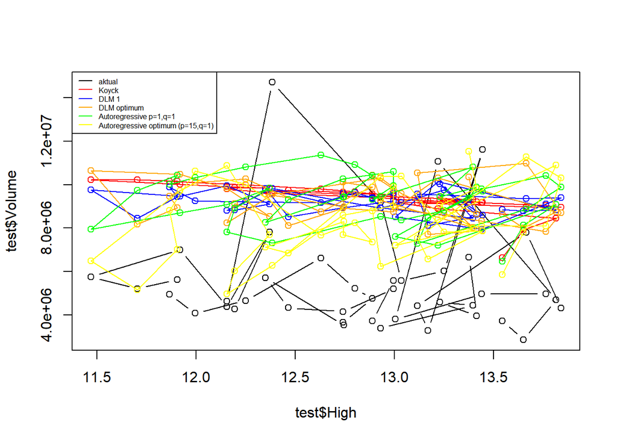

```r
par(mfrow=c(1,1))
plot(test$High, test$Volume, type="b", col="black")
points(test$High, frc.koyck$forecasts,col="red")
lines(test$High, frc.koyck$forecasts,col="red")
points(test$High, frc.dl$forecasts,col="blue")
lines(test$High, frc.dl$forecasts,col="blue")
points(test$High, frc.dl.opt$forecasts,col="orange")
lines(test$High, frc.dl.opt$forecasts,col="orange")
points(test$High, frc.ardl$forecasts,col="green")
lines(test$High, frc.ardl$forecasts,col="green")
points(test$High, frc.ardl.opt$forecasts,col="yellow")
lines(test$High, frc.ardl.opt$forecasts,col="yellow")
legend("topleft",c("aktual", "Koyck","DLM 1","DLM optimum","Autoregressive p=1,q=1", "Autoregressive optimum (p=15,q=1)"), lty=1, col=c("black","red","blue","orange","green","yellow"), cex=0.5)
```